# Natural versus synthetic ACTH for infantile spasms

We evaluate here whether natural and synthetic ACTH are associated with different effectiveness controlling infantile spasms.

## Install needed package

```r
# install.packages("meta")
library (meta)
```

```
## Loading 'meta' package (version 4.9-7).
## Type 'help(meta)' for a brief overview.
```

## ACTH

#### ACTH data

Data from the studies on the effectiveness of ACTH for infantile spasms.

```r
# ACTH data
ACTH <- metaprop(
  event = c( 7, 12, 13, 14, 11, 19, 46, 17, 11, 18, 66, 40,  52,  9, 11),
  n = c(    12, 15, 15, 19, 13, 25, 53, 20, 14, 49, 97, 57, 111, 18, 16),
  studlab = c(
              "Hrachovy et al, 1983",
              "Snead et al, 1989",
              "Baram et al, 1996",
              "Vigevano & Cilio, 1997",
              "Yanagaki et al, 1999",
              "Lux et al, 2004",
              "Lin et al, 2006",
              "Kossoff et al, 2008",
              "Cohen-Sadan et al, 2009",
              "Wanigasinghe et al, 2015",
              "Knupp et al, 2016",
              "Hodgeman et al, 2016",
              "Yin et al, 2017",
              "Gowda et al, 2019",
              "Dressler et al, 2019"
  ),
  method="Inverse"
               )
```

##### ACTH forest plot

Forest plot summarizing the data on effectiveness for ACTH for infantile spasms (probability of resolving infantile spasms 2 weeks after treatment initiation).

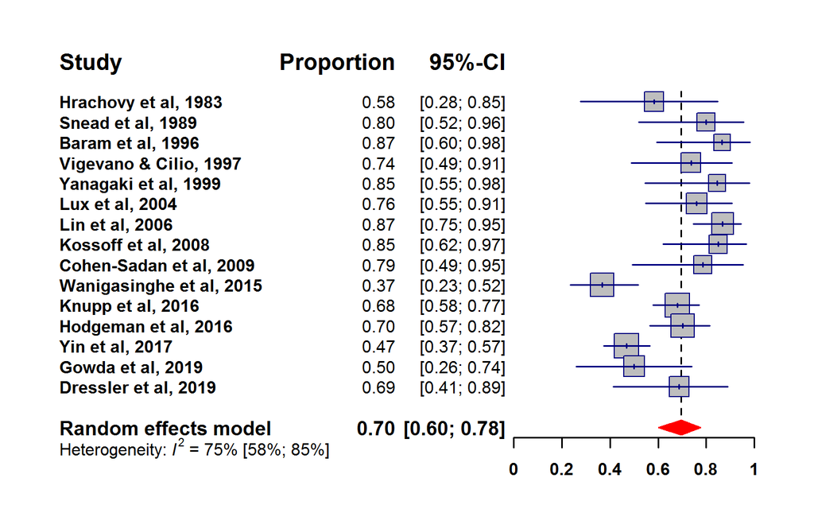

```r
# Forest plot
forest(ACTH, comb.fixed = FALSE, lty.random=2, lty.fixed = 0,
       xlim = c(0, 1), lwd = 1.75, col.study = "navy", col.square = "gray", col.square.lines = "navy",
       col.diamond.random = "red", col.diamond.lines.random = "red",
       print.I2 = TRUE, print.I2.ci = TRUE, print.tau2 = FALSE, print.pval.Q = FALSE,
       fontsize = 12, fs.heading = 16, fs.hetstat = 12, fs.axis = 12, fs.test.overall = 12,
       fs.random = 14, fs.smlab = 14, ff.study.labels =  "bold",
       ff.axis = "bold", squaresize = 1.2,
       backtransf = TRUE, test.overall.random = TRUE,
       leftcols = c("studlab", "effect", "ci"), rightcols = FALSE,
       just = "right", digits = 2)
```

The forest plot for this random-effects meta-analysis shows that the estimated effectiveness (probability of resolving infantile spasms at 2 weeks after treatment) of ACTH is 70%, with a 95% confidence interval between 60% and 78%.

It also shows that there is significant between-study heterogeneity with an $I^2$ of 75% (95% confidence interval: 58% to 85%).

We evaluated whether there was a different effectiveness among patients using natural ACTH and synthetic ACTH.

#### ACTH by subgroups (natural versus synthetic) data

Data from the studies on the effectiveness of natural versus synthetic ACTH for infantile spasms.

```r
# Metaanalysis considering subgroups by AED
ACTH_subgroups <- metaprop(event = c(7, 12, 13, 17, 11, 66, 40, 52,  9,                    ### NATURAL
                                    14, 11, 19, 46, 18, 11),                               ### SYNTHETIC

               n = c(               12, 15, 15, 20, 14, 97, 57, 111, 18,                   ### NATURAL
                                    19, 13, 25, 53, 49, 16),                               ### SYNTHETIC

               studlab =
                 c("Hrachovy et al, 1983",
                 "Snead et al, 1989",
                 "Baram et al, 1996",
                 "Kossoff et al, 2008",
                 "Cohen-Sadan et al, 2009",
                 "Knupp et al, 2016",
                 "Hodgeman et al, 2016",
                 "Yin et al, 2017",
                 "Gowda et al, 2019",                                                      ### NATURAL

                 "Vigevano & Cilio, 1997",
                 "Yanagaki et al, 1999",
                 "Lux et al, 2004",
                 "Lin et al, 2006",
                 "Wanigasinghe et al, 2015",
                 "Dressler et al, 2019"),                                                  ### SYNTHETIC


               byvar = c("Natural", "Natural", "Natural", "Natural", "Natural",
                         "Natural", "Natural", "Natural", "Natural",                       ### NATURAL

                         "Synthetic", "Synthetic", "Synthetic", "Synthetic", "Synthetic",
                         "Synthetic"),                                                     ### SYNTHETIC
  method="Inverse"
  )
```

#### ACTH by subgroups (natural versus synthetic) forest plot

Forest plot summarizing the data on effectiveness (probability of resolving infantile spasms 2 weeks after treatment initiation) for natural versus synthetic ACTH.

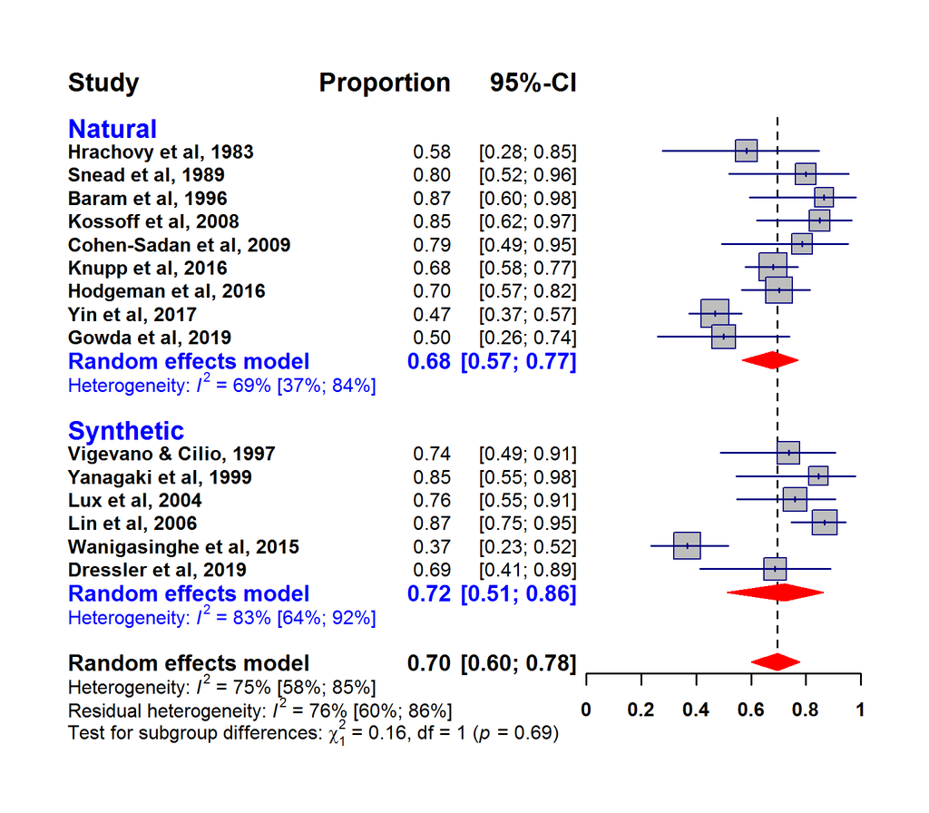

```r
# Forest plot
forest(ACTH_subgroups, comb.fixed = FALSE, lty.random=2, lty.fixed = 0,
       xlim = c(0, 1), lwd = 1.75, col.study = "navy", col.square = "gray", col.square.lines = "navy",
       col.diamond.random = "red", col.diamond.lines.random = "red",
       print.I2 = TRUE, print.I2.ci = TRUE, print.tau2 = FALSE, print.pval.Q = FALSE,
       fontsize = 12, fs.heading = 16, fs.hetstat = 12, fs.axis = 12, fs.test.overall = 12,
       fs.random = 14, fs.smlab = 14, ff.study.labels =  "bold",
       ff.axis = "bold", squaresize = 1.2,
       backtransf = TRUE, test.overall.random = TRUE,
       leftcols = c("studlab", "effect", "ci"), rightcols = FALSE,
       just = "right", digits = 2, bylab = "DOSE",
       print.byvar = FALSE, col.by = "blue", overall = TRUE, overall.hetstat = TRUE,
       test.subgroup.random = TRUE, fs.test.subgroup.random = 15)
```

This forest plot shows that the overall estimation of effectiveness of ACTH: 70% (95% confidence interval: 60% to 78%) is a composite of two very similar estimates:

-The effectiveness of natural ACTH: 68% (95% confidence interval: 57% to 77%).

-The effectiveness of synthetic ACTH: 72% (95% confidence interval: 51% to 86%).

The difference in effectiveness between the natural ACTH and synthetic ACTH subgroups is not statistically significant with a p-value of 0.69.

The division in natural and synthetic does not account for much heterogeneity with similar $I^2$ within each of the two groups.

## ACTH data evaluating subgroups for potential publication bias

#### Natural ACTH evaluation for potential publication bias

Data from the studies on the effectiveness of natural ACTH for infantile spasms.

```r
# Natural ACTH data
Natural_ACTH <- metaprop(
  event = c( 7, 12, 13, 17, 11, 66, 40, 52,   9),
  n = c(    12, 15, 15, 20, 14, 97, 57, 111, 18),
  studlab = c(
              "Hrachovy et al, 1983",
                 "Snead et al, 1989",
                 "Baram et al, 1996",
                 "Kossoff et al, 2008",
                 "Cohen-Sadan et al, 2009",
                 "Knupp et al, 2016",
                 "Hodgeman et al, 2016",
                 "Yin et al, 2017",
                 "Gowda et al, 2019"
  ),
  method="Inverse"
               )
```

Forest plot summarizing the data on effectiveness for natural ACTH for infantile spasms

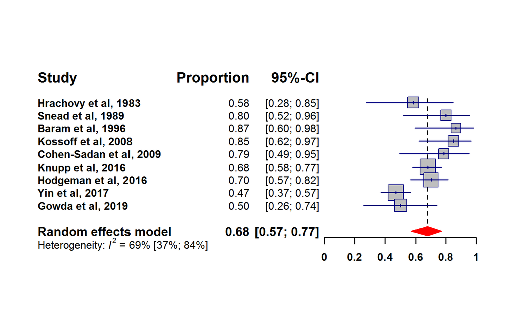

```r
# Forest plot
forest(Natural_ACTH, comb.fixed = FALSE, lty.random=2, lty.fixed = 0,
       xlim = c(0, 1), lwd = 1.75, col.study = "navy", col.square = "gray", col.square.lines = "navy",
       col.diamond.random = "red", col.diamond.lines.random = "red",
       print.I2 = TRUE, print.I2.ci = TRUE, print.tau2 = FALSE, print.pval.Q = FALSE,
       fontsize = 12, fs.heading = 16, fs.hetstat = 12, fs.axis = 12, fs.test.overall = 12,
       fs.random = 14, fs.smlab = 14, ff.study.labels =  "bold",
       ff.axis = "bold", squaresize = 1.2,
       backtransf = TRUE, test.overall.random = TRUE,
       leftcols = c("studlab", "effect", "ci"), rightcols = FALSE,
       just = "right", digits = 2)
```

Small studies tend to have more extreme results (either more positive or more negative results) just because a smaller sample size leads to more variability in the estimate than a larger sample size.

However, positive results tend to be published more often than negative results, leading to publication bias.

We evaluate publication bias visually through a funnel plot.

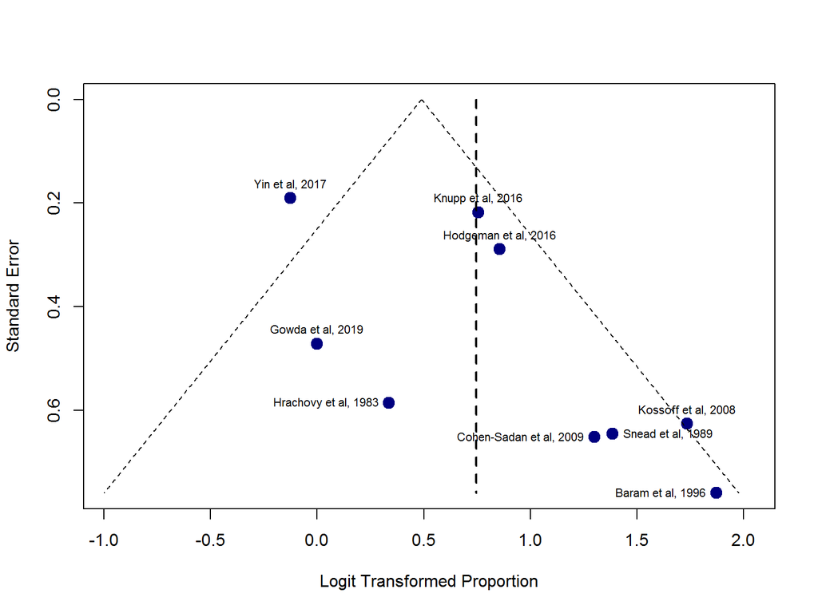

```r
# Funnel plot names
funnel(Natural_ACTH, comb.fixed = FALSE, comb.random = TRUE, pch = 21, cex = 1.5,
       lty.random = 2, lwd.random = 2, bg = "navy", col = "navy",
       studlab = TRUE, cex.studlab = 0.7, pos.studlab = c(2, 4, 2, 3, 2, 3, 3, 3, 3))
```

This funnel plot shows that small studies (low on the y-axis) tend to have estimates of the effectiveness of ACTH higher (right on the x-axis) than larger studies suggesting some degree of publication bias leading to some degree of overestimation of the effectiveness of ACTH.

The trim and fill method artificially compensates for the studies that are probably causing publication bias (small studies that are distributed asymmetrically) artificially creating small studies simetrically distributed from the existing small studies (studies which probably existed but probably were not published).

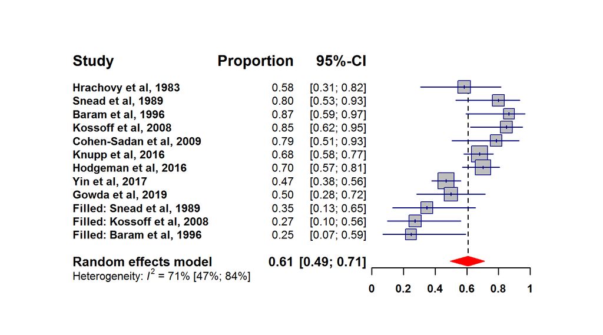

```r
# Natural ACTH data trimandfill
Natural_ACTH_trimandfill <- trimfill(Natural_ACTH, ma.fixed = TRUE, comb.random = TRUE)

# Forest plot
forest(Natural_ACTH_trimandfill, comb.fixed = FALSE, lty.random=2, lty.fixed = 0,
       xlim=c(0, 1), lwd = 1.75, col.study = "navy", col.square = "gray", col.square.lines = "navy",
       col.diamond.random = "red", col.diamond.lines.random = "red",
       print.I2 = TRUE, print.I2.ci = TRUE, print.tau2 = FALSE, print.pval.Q = FALSE,
       fontsize = 12, fs.heading = 16, fs.hetstat = 12, fs.axis = 12, fs.test.overall = 12,
       fs.random = 14, fs.smlab = 14, ff.study.labels =  "bold",
       ff.axis = "bold", squaresize = 1.2,
       backtransf = TRUE, test.overall.random = FALSE,
       leftcols = c("studlab", "effect", "ci"), rightcols = FALSE,
       just = "right", digits = 2, print.zval = FALSE, label.test.overall.random = FALSE)
```

The forest plot imputing studies that “adjust” for potential publication bias show that, potentially, without publication bias, the pooled estimate of effectiveness of natural ACTH would be approximately 61% with a 95% confidence interval from 49% to 71%.

That is somewhat lower than the unadjusted estimate of 68%, with a 95% confidence interval from 57% to 77%. This suggests that the effectiveness of natural ACTH around 68% is probably inflated through publication bias.

We evaluate publication bias visually through a funnel plot.

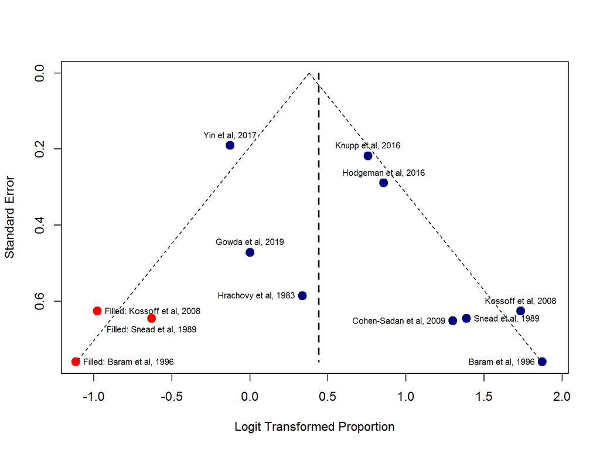

```r
# Funnel plot
funnel(Natural_ACTH_trimandfill, comb.fixed = FALSE, comb.random = TRUE, pch = 21, cex = 1.5,
       lty.random = 2, lwd.random = 2,
       bg = c("navy", "navy", "navy", "navy", "navy", "navy", "navy", "navy", "navy", "red", "red", "red"),
       col = c("navy", "navy", "navy", "navy", "navy", "navy", "navy", "navy", "navy", "red", "red", "red"),
       studlab = TRUE, cex.studlab = 0.7, pos.studlab = c(2, 4, 2, 3, 2, 3, 3, 3, 3, 1, 4, 4))
```

Obviously, “adjusting” for potential publication bias shows a more balanced plot. In red, the inputted studies to compensate for potential publication bias.

#### Synthetic ACTH evaluation for potential publication bias

Data from the studies on the effectiveness of synthetic ACTH for infantile spasms.

```r
# Synthetic ACTH data
Synthetic_ACTH <- metaprop(
  event = c( 14, 11, 19, 46, 18, 11),
  n = c(     19, 13, 25, 53, 49, 16),
  studlab = c(
              "Vigevano & Cilio, 1997",
               "Yanagaki et al, 1999",
               "Lux et al, 2004",
               "Lin et al, 2006",
               "Wanigasinghe et al, 2015",
               "Dressler et al, 2019"
  ),
  method="Inverse"
               )
```

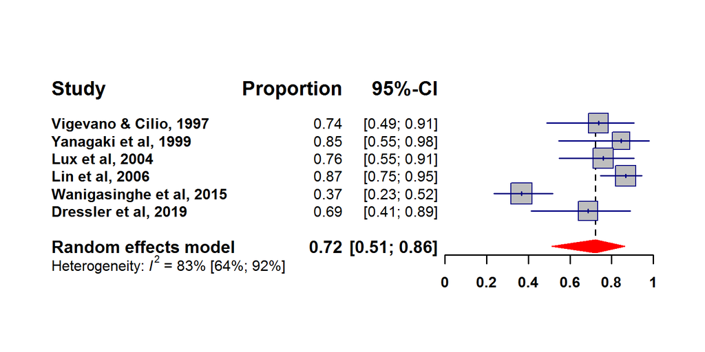

```r
# Forest plot
forest(Synthetic_ACTH, comb.fixed = FALSE, lty.random=2, lty.fixed = 0,
       xlim = c(0, 1), lwd = 1.75, col.study = "navy", col.square = "gray", col.square.lines = "navy",
       col.diamond.random = "red", col.diamond.lines.random = "red",
       print.I2 = TRUE, print.I2.ci = TRUE, print.tau2 = FALSE, print.pval.Q = FALSE,
       fontsize = 12, fs.heading = 16, fs.hetstat = 12, fs.axis = 12, fs.test.overall = 12,
       fs.random = 14, fs.smlab = 14, ff.study.labels =  "bold",
       ff.axis = "bold", squaresize = 1.2,
       backtransf = TRUE, test.overall.random = TRUE,
       leftcols = c("studlab", "effect", "ci"), rightcols = FALSE,
       just = "right", digits = 2)
```

Small studies tend to have more extreme results (either more positive or more negative results) just because a smaller sample size leads to more variability in the estimate than a larger sample size.

However, positive results tend to be published more often than negative results, leading to publication bias.

We evaluate publication bias visually through a funnel plot.

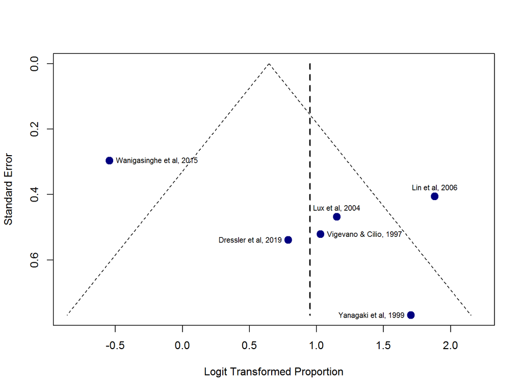

```r
# Funnel plot names
funnel(Synthetic_ACTH, comb.fixed = FALSE, comb.random = TRUE, pch = 21, cex = 1.5,
       lty.random = 2, lwd.random = 2, bg = "navy", col = "navy",
       studlab = TRUE, cex.studlab = 0.7, pos.studlab = c(4, 2, 3, 3, 4, 2))
```

This funnel plot shows that small studies (low on the y-axis) tend to have estimates of the effectiveness of ACTH higher (right on the x-axis) than larger studies suggesting some degree of publication bias leading to some degree of overestimation of the effectiveness of ACTH.

The trim and fill method artificially compensates for the studies that are probably causing publication bias (small studies that are distributed asymmetrically) artificially creating small studies simetrically distributed from the existing small studies (studies which probably existed but probably were not published).

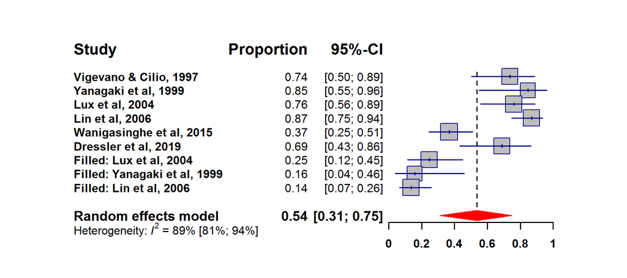

```r
# Synthetic ACTH data trimandfill
Synthetic_ACTH_trimandfill <- trimfill(Synthetic_ACTH, ma.fixed = TRUE, comb.random = TRUE)

# Forest plot
forest(Synthetic_ACTH_trimandfill, comb.fixed = FALSE, lty.random=2, lty.fixed = 0,
       xlim=c(0, 1), lwd = 1.75, col.study = "navy", col.square = "gray", col.square.lines = "navy",
       col.diamond.random = "red", col.diamond.lines.random = "red",
       print.I2 = TRUE, print.I2.ci = TRUE, print.tau2 = FALSE, print.pval.Q = FALSE,
       fontsize = 12, fs.heading = 16, fs.hetstat = 12, fs.axis = 12, fs.test.overall = 12,
       fs.random = 14, fs.smlab = 14, ff.study.labels =  "bold",
       ff.axis = "bold", squaresize = 1.2,
       backtransf = TRUE, test.overall.random = FALSE,
       leftcols = c("studlab", "effect", "ci"), rightcols = FALSE,
       just = "right", digits = 2, print.zval = FALSE, label.test.overall.random = FALSE)
```

The forest plot imputing studies that “adjust” for potential publication bias show that, potentially, without publication bias, the pooled estimate of effectiveness of synthetic ACTH would be approximately 54% with a 95% confidence interval from 31% to 75%.

That is lower than the unadjusted estimate of 72%, with a 95% confidence interval from 51% to 86%. This suggests that the effectiveness of synthetic ACTH around 72% is probably inflated through publication bias.

We evaluate publication bias visually through a funnel plot.

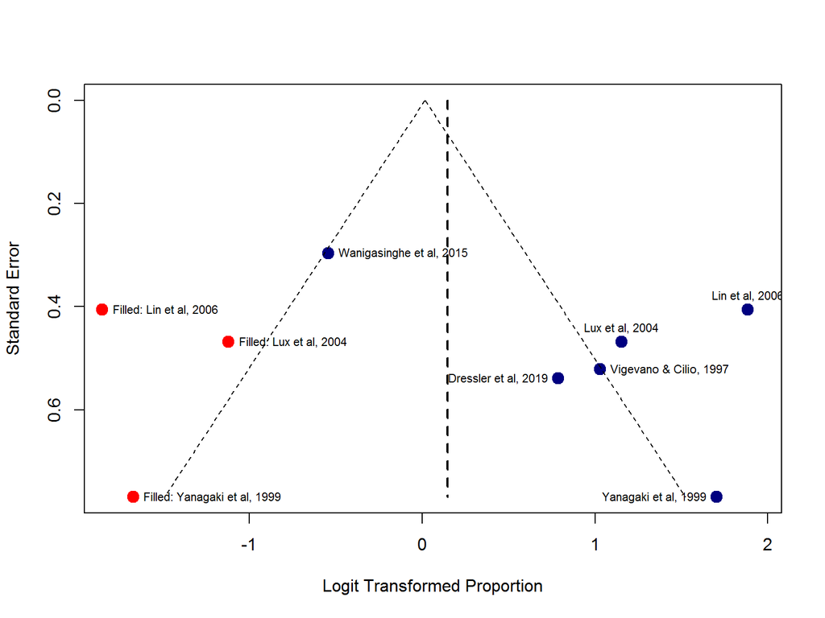

```r
# Funnel plot
funnel(Synthetic_ACTH_trimandfill, comb.fixed = FALSE, comb.random = TRUE, pch = 21, cex = 1.5,
       lty.random = 2, lwd.random = 2,
       bg = c("navy", "navy", "navy", "navy", "navy", "navy", "red", "red", "red"),
       col = c("navy", "navy", "navy", "navy", "navy", "navy", "red", "red", "red"),
       studlab = TRUE, cex.studlab = 0.7, pos.studlab = c(4, 2, 3, 3, 4, 2, 4, 4, 4))
```

Obviously, “adjusting” for potential publication bias shows a more balanced plot. In red, the inputted studies to compensate for potential publication bias.

#### Comparison of natural versus synthetic ACTH evaluating for potential publication bias

Data from the studies on the effectiveness of natural and synthetic ACTH for infantile spasms adjusting for potential publication bias.

```r
# Meta-analysis considering subgroups by groups: natural and synthetic ACTH
COMPARISON_NaturalvsSynthetic_ACTH <- metagen(TE = c(Natural_ACTH_trimandfill$TE,         ### NATURAL
                                                     Synthetic_ACTH_trimandfill$TE),      ### SYNTHETIC

               seTE = c(              Natural_ACTH_trimandfill$seTE,                      ### NATURAL
                                      Synthetic_ACTH_trimandfill$seTE),                   ### SYNTHETIC

               studlab = c(Natural_ACTH_trimandfill$studlab,                              ### NATURAL
                           Synthetic_ACTH_trimandfill$studlab),                           ### SYNTHETIC


               byvar = c(
                         rep("Natural", length(Natural_ACTH_trimandfill$studlab)),        ### NATURAL
                         rep("Synthetic", length(Synthetic_ACTH_trimandfill$studlab))     ### SYNTHETIC
),
  sm = "PLOGIT"
               )
```

Forest plot comparison natural versus synthetic ACTH adjusting for publication bias

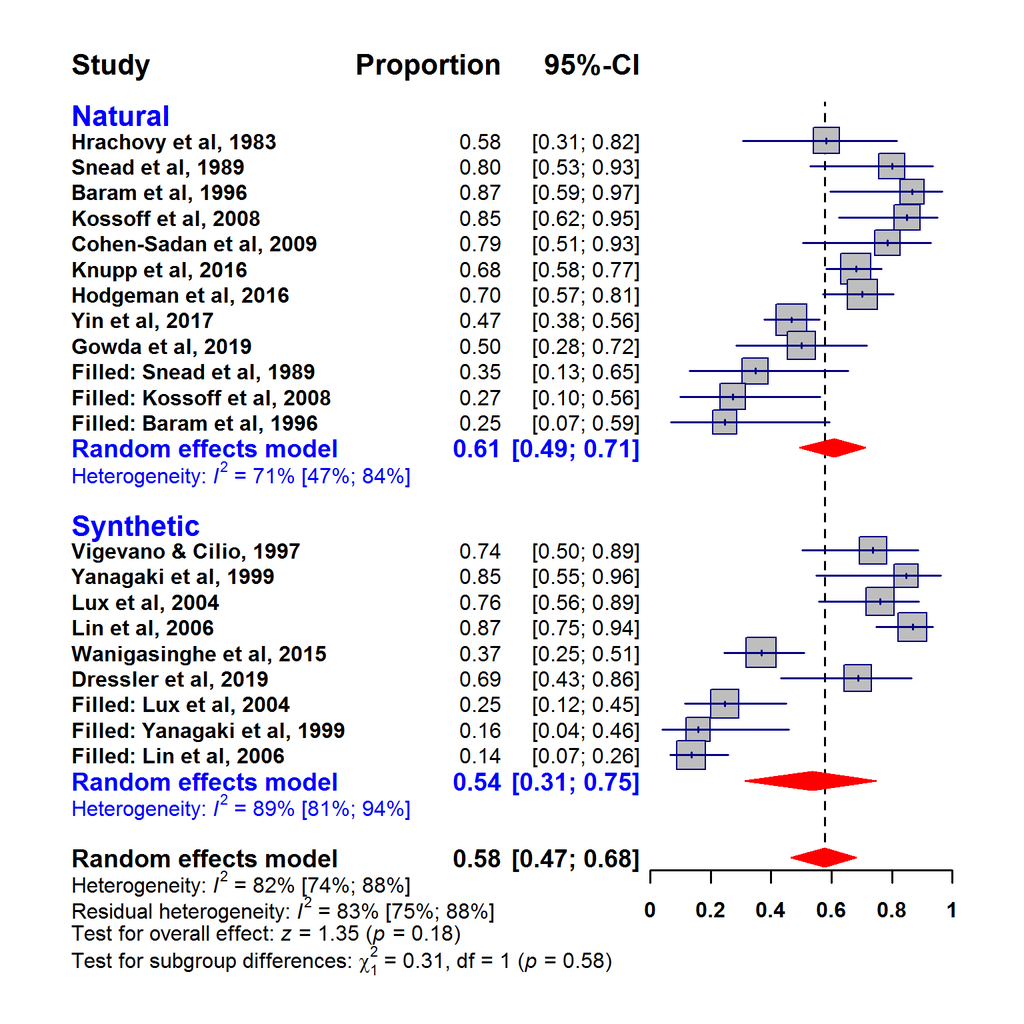

```r
forest(COMPARISON_NaturalvsSynthetic_ACTH, comb.fixed = FALSE, lty.random=2, lty.fixed = 0,
       xlim = c(0, 1), lwd = 1.75, col.study = "navy", col.square = "gray", col.square.lines = "navy",
       col.diamond.random = "red", col.diamond.lines.random = "red",
       print.I2 = TRUE, print.I2.ci = TRUE, print.tau2 = FALSE, print.pval.Q = FALSE,
       fontsize = 12, fs.heading = 16, fs.hetstat = 12, fs.axis = 12, fs.test.overall = 12,
       fs.random = 14, fs.smlab = 14, ff.study.labels =  "bold",
       ff.axis = "bold", squaresize = 1.2,
       backtransf = TRUE, test.overall.random = TRUE,
       leftcols = c("studlab", "effect", "ci"), rightcols = FALSE,
       just = "right", digits = 2, bylab = "MEDICATION",
       print.byvar = FALSE, col.by = "blue", overall = TRUE, overall.hetstat = TRUE,
       test.subgroup.random = TRUE, fs.test.subgroup.random = 15)
```

This forest plot shows that the overall estimation of effectiveness of ACTH after adjusting for potential publication bias is: 58% (95% confidence interval: 47% to 68%) is a composite of two very similar estimates:

-The effectiveness of natural ACTH: 61% (95% confidence interval: 49% to 71%).

-The effectiveness of synthetic ACTH: 54% (95% confidence interval: 31% to 75%).

The difference in effectiveness between the natural ACTH and synthetic ACTH subgroups is not statistically significant with a p-value of 0.58.

The division in natural and synthetic does not account for much heterogeneity with similar $I^2$ within each of the two groups.

#### Therefore, we will continue the rest of the analysis considering ACTH as one group with one effectiveness regardless of whether ACTH is natural or synthetic.